# Wine research

Alexander Andreev

17 April 2018

Let’s read the data first and show datatypes and basic statistics.

```r
library(gridExtra)
#library(psych)
library(moments)
library(pastecs)
library(sm)
library(RColorBrewer)
library(vioplot)
library(ggplot2)
#library(caret)
library(rcompanion)
```

```r
set.seed(22)
theme_update(plot.title = element_text(hjust = 0.5))
path <- 'c:/Users/fyva/workspace/Udacity/Wine/'
setwd(path)
vinho_set <- read.csv('wineQualityReds.csv')
str(vinho_set)
```

```
'data.frame':   1599 obs. of  13 variables:
 $ id                  : int  1 2 3 4 5 6 7 8 9 10 ...
 $ fixed.acidity       : num  7.4 7.8 7.8 11.2 7.4 7.4 7.9 7.3 7.8 7.5 ...
 $ volatile.acidity    : num  0.7 0.88 0.76 0.28 0.7 0.66 0.6 0.65 0.58 0.5 ...
 $ citric.acid         : num  0 0 0.04 0.56 0 0 0.06 0 0.02 0.36 ...
 $ residual.sugar      : num  1.9 2.6 2.3 1.9 1.9 1.8 1.6 1.2 2 6.1 ...
 $ chlorides           : num  0.076 0.098 0.092 0.075 0.076 0.075 0.069 0.065 0.073 0.071 ...
 $ free.sulfur.dioxide : num  11 25 15 17 11 13 15 15 9 17 ...
 $ total.sulfur.dioxide: num  34 67 54 60 34 40 59 21 18 102 ...
 $ density             : num  0.998 0.997 0.997 0.998 0.998 ...
 $ pH                  : num  3.51 3.2 3.26 3.16 3.51 3.51 3.3 3.39 3.36 3.35 ...
 $ sulphates           : num  0.56 0.68 0.65 0.58 0.56 0.56 0.46 0.47 0.57 0.8 ...
 $ alcohol             : num  9.4 9.8 9.8 9.8 9.4 9.4 9.4 10 9.5 10.5 ...
 $ quality             : int  5 5 5 6 5 5 5 7 7 5 ...
```

```r
cat('\n')
```

```r
summary(vinho_set[,c(2:7)])
```

```
 fixed.acidity   volatile.acidity  citric.acid    residual.sugar    chlorides     free.sulfur.dioxide
 Min.   : 4.60   Min.   :0.120    Min.   :0.000   Min.   : 0.90   Min.   :0.012   Min.   : 1.0
 1st Qu.: 7.10   1st Qu.:0.390    1st Qu.:0.090   1st Qu.: 1.90   1st Qu.:0.070   1st Qu.: 7.0
 Median : 7.90   Median :0.520    Median :0.260   Median : 2.20   Median :0.079   Median :14.0
 Mean   : 8.32   Mean   :0.528    Mean   :0.271   Mean   : 2.54   Mean   :0.087   Mean   :15.9
 3rd Qu.: 9.20   3rd Qu.:0.640    3rd Qu.:0.420   3rd Qu.: 2.60   3rd Qu.:0.090   3rd Qu.:21.0
 Max.   :15.90   Max.   :1.580    Max.   :1.000   Max.   :15.50   Max.   :0.611   Max.   :72.0
```

```r
cat('\n')
```

```r
summary(vinho_set[,c(8:13)])
```

```
 total.sulfur.dioxide    density            pH         sulphates        alcohol        quality
 Min.   :  6.0        Min.   :0.990   Min.   :2.74   Min.   :0.330   Min.   : 8.4   Min.   :3.00
 1st Qu.: 22.0        1st Qu.:0.996   1st Qu.:3.21   1st Qu.:0.550   1st Qu.: 9.5   1st Qu.:5.00
 Median : 38.0        Median :0.997   Median :3.31   Median :0.620   Median :10.2   Median :6.00
 Mean   : 46.5        Mean   :0.997   Mean   :3.31   Mean   :0.658   Mean   :10.4   Mean   :5.64
 3rd Qu.: 62.0        3rd Qu.:0.998   3rd Qu.:3.40   3rd Qu.:0.730   3rd Qu.:11.1   3rd Qu.:6.00
 Max.   :289.0        Max.   :1.004   Max.   :4.01   Max.   :2.000   Max.   :14.9   Max.   :8.00
```

```r
vinho_set$fquality <- factor(vinho_set$quality, ordered = TRUE)
```

Let’s check missing data in the dataset: it is exactly 0 entries overall.

```r
#sum(is.na(vinho_set))
#data.frame(sapply(vinho_set, function(x) sum(is.na(x))))
```

### Univariate Plots Section

Let’s take a look at the diagrams of the distribution of variables

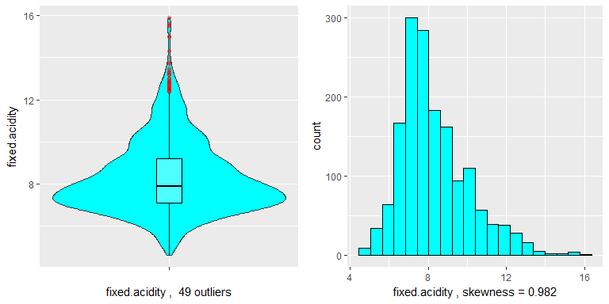

```r
drow_distrib <- function(df, pred, hist_bins){
  pp <- list()
  pp[[1]] <- ggplot(df, aes_string(x=factor(''), y=pred))+ geom_violin( fill='cyan')+
    geom_boxplot(outlier.colour = 'red', alpha=0.3, color="black", width=.1) +
    xlab(paste(pred, ', ', length(boxplot.stats(vinho_set[[pred]])$out),
               ifelse(length(boxplot.stats(vinho_set[[pred]])$out)==1, 'outlier', 'outliers')))

  pp[[2]] <- ggplot(df, aes_string(x=pred)) + geom_histogram(bins=hist_bins, colour="black", fill="cyan") +
    xlab(paste(pred, ', skewness =', round(skewness(df[pred]),3)))

  grid.arrange(pp[[1]], pp[[2]], ncol=2)
}
drow_distrib(vinho_set, 'fixed.acidity', 20)
```

Varable fixed.acidity has right skewed distribution and has 49 outliers (points in red). Outliers can not be removed on the basis of single field data only. With a large number of outliers and the impossibility of manual testing, the use of the multivariate verification procedure is necessary, e.g. Mahalanobis distance.

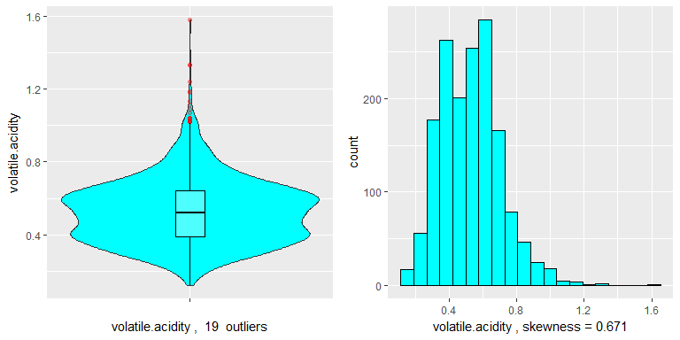

Variable volatile.acidity is also right skewed and has 19 outliers.

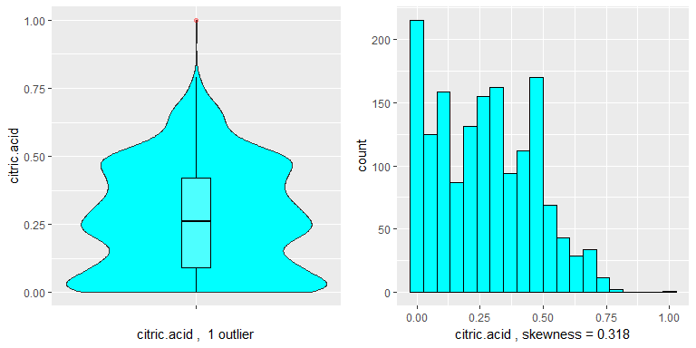

Variable citric.acid is also right skewed and has 1 outlier only.

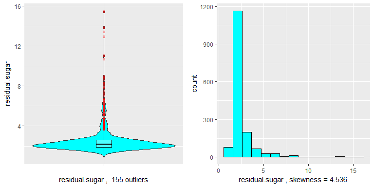

Variable residual.sugar is extremly skewed and has 155 outliers. Most values are located in the region of 2 g/l

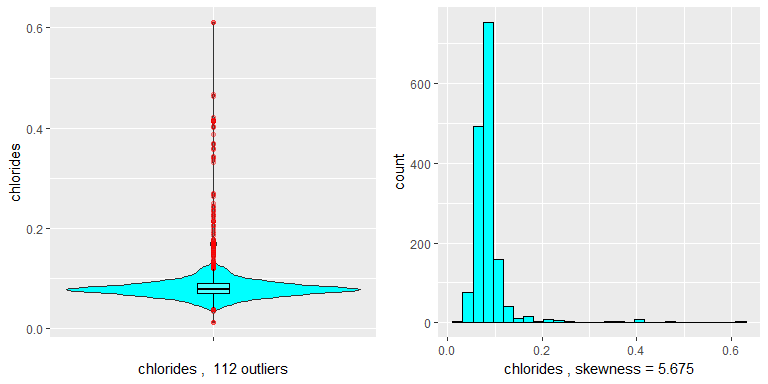

Variable chlorides is also extremly skewed and has 112 outliers. Most values are located in the region of 0.08 g/l

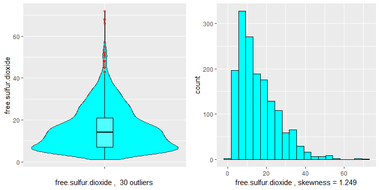

Variable free.sulfur.dioxide is right skewed and has 30 outliers.

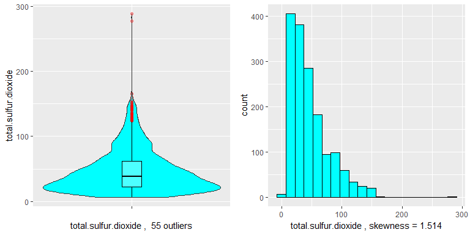

Variable total.sulfur.dioxide is also right skewed and has 55 outliers.

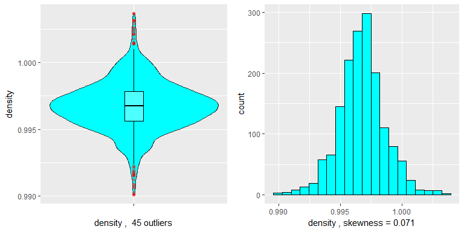

Variable density has normal distribution and has 45 outliers.

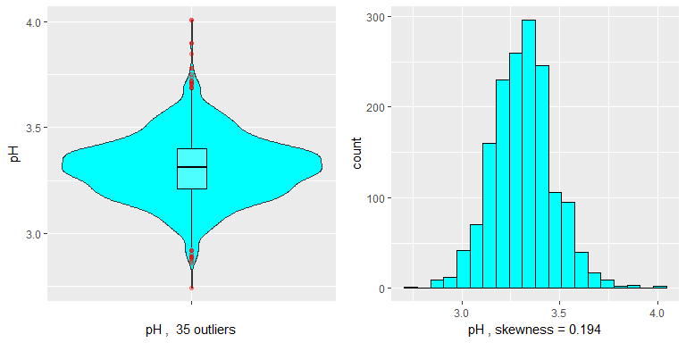

Variable pH has normal distribution and has 35 outliers.

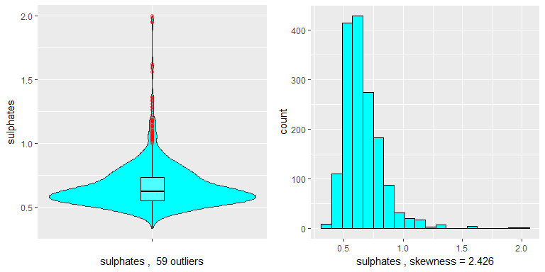

Varable sulphates has right skewed distribution and has 59 outliers

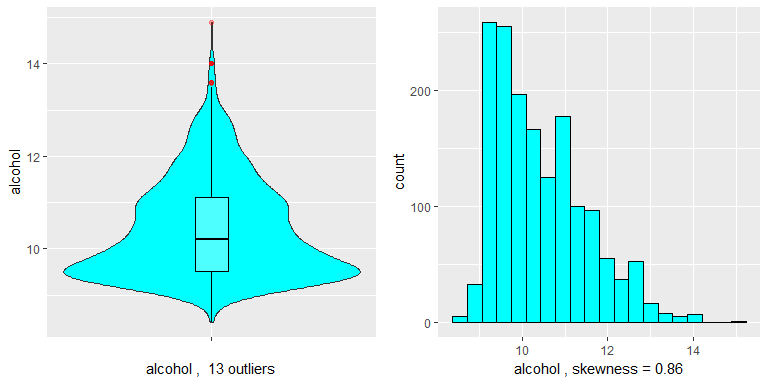

Varable alcohol has right skewed distribution and has 13 outliers

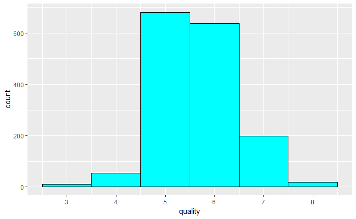

```r
pred <- 'quality'
ggplot(vinho_set, aes_string(x=pred)) + geom_histogram(bins=6, colour="black", fill="cyan") +
    scale_x_continuous(breaks = seq(3,8)) +
    xlab(pred)
```

Target variable. Tukey’s fences method considers the first and last classes of the target variable as outliers.

One predictor citric.acid has 132 entries with zero values. Let’s check the distributions of these observations:

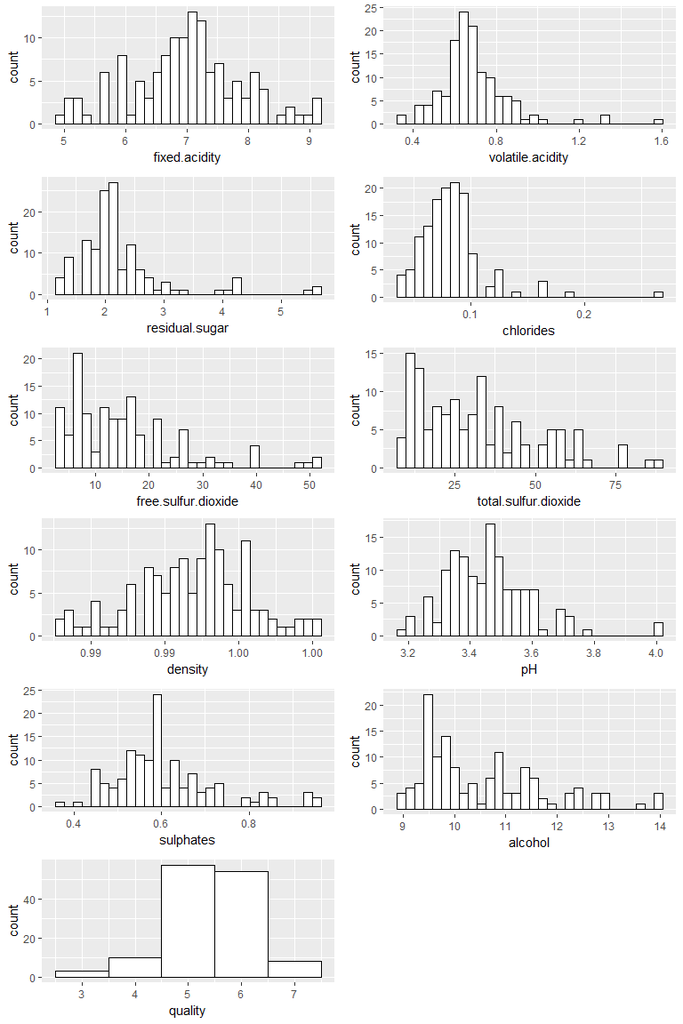

```r
#sum(vinho_set$citric.acid==0)
p <- ggplot(vinho_set[vinho_set$citric.acid==0,]) + geom_histogram(colour="black", fill="white")
pp <- list()
for(nn in names(vinho_set[,!names(vinho_set) %in% c('id','citric.acid','quality')])) {
  pp[[nn]] <- p + aes_string(x=nn)
}
pp[[nn]] <- p + aes_string(x='quality') + geom_histogram(colour="black", fill="white", bins=5)
do.call(grid.arrange,c(pp, ncol=2, nrow=6))
```

There is no significant difference with the rest. The best wines should contain citric acid.

Let’s check the variance:

```r
options(scipen=100)
options(digits=2)
x <- stat.desc(vinho_set, basic = FALSE)
x$predictors <- rownames(x)
#rownames(x) <- NULL
print(t(x[5, c(2:12)]))
```

```
                              var
fixed.acidity           3.0314164
volatile.acidity        0.0320624
citric.acid             0.0379475
residual.sugar          1.9878971
chlorides               0.0022151
free.sulfur.dioxide   109.4148838
total.sulfur.dioxide 1082.1023725
density                 0.0000036
pH                      0.0238352
sulphates               0.0287326
alcohol                 1.1356474
```

Two predictors chlorides and density have small variance. Let’s check these two variables with nearZeroVar method for the possibility of removing them:

```r
x = nearZeroVar(vinho_set[,c('chlorides','density')], saveMetrics = TRUE)
x$predictors <- rownames(x)
rownames(x) <- NULL
print(x[, c(5, 1:4)])
```

| predictors | freqRatio | percentUnique | zeroVar | nzv |
| --- | --- | --- | --- | --- |
| chlorides | 1.20 | 9.57 | FALSE | FALSE |
| density | 1.03 | 27.27 | FALSE | FALSE |

Analysis shows that no variable can be excluded by this method.

### Univariate Analysis

The Dataset is well organized and cleaned. To calculate statistics that require a normal distribution, two predictors free.sulfur.dioxide and total.sulfur.dioxide can be normalized by the logarithmic transformation. To normalize other skewed variables, you need a more accurate fit, for example, using the the Tukey ladder of powers. 132 vines or 8% have zero content of citric acid. The target variable is uneven distributed. A small amount of data by classes 3 and 8 will decrease the significance of any assumption or prediction. Outliers in data can distort predictions and affect the accuracy of a model.

### Bivariate Plots Section

Full matrix shows Pearson correlation, histograms and bivariate scatterplots. Linear regression is also shown.

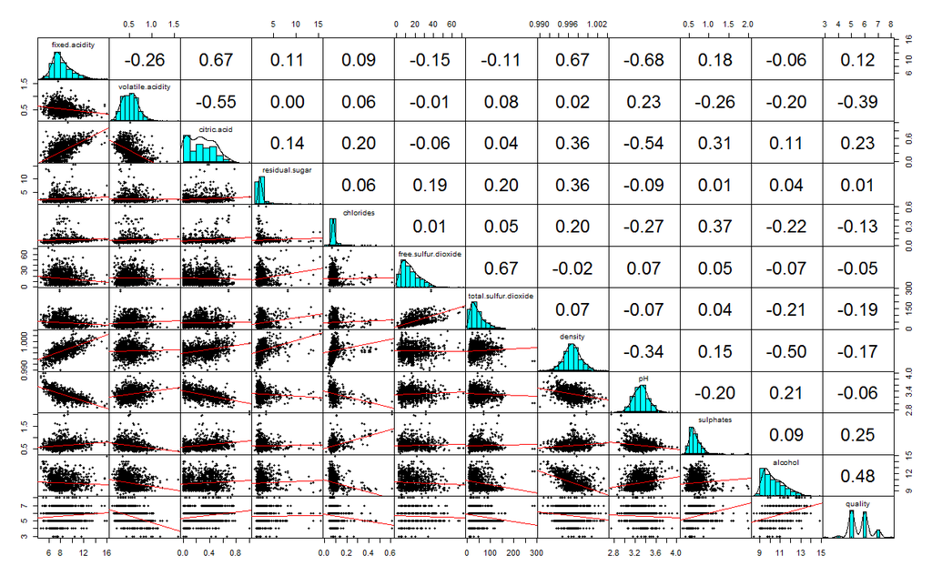

```r
options(digits=2)
pairs.panels(vinho_set[,2:13], gap=0, lm=TRUE, ellipses=FALSE)
```

```r
#,jiggle=TRUE, pch=21, bg=c('red','orange','yellow','green','blue','purple')[vinho_set$quality])
```

Before analyzing the pairs of properties, let’s consider the distribution density by quality. This plot series reflects the last column of the correlation matrix.

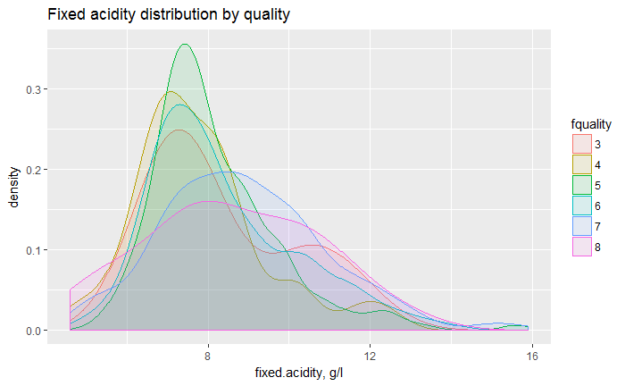

Wine classes are equally distributed throughout the range. Classes 7 and 8 have a slightly wider bell distribution. The others have a maximum about 7 g/l of tartaric acid.

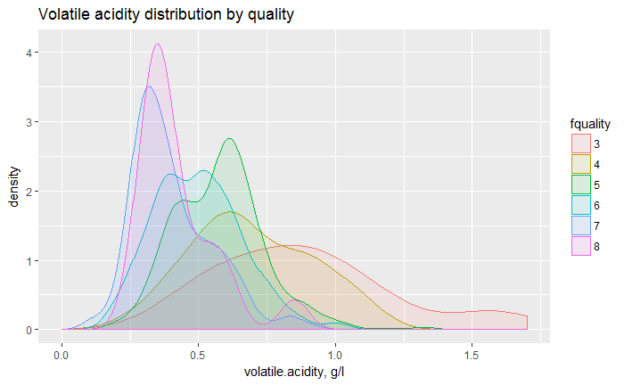

It is obvious that wine class falls with growing of volatile acidity or acetic acid concentration. Here we can definitely talk about the cause-effect relationship.

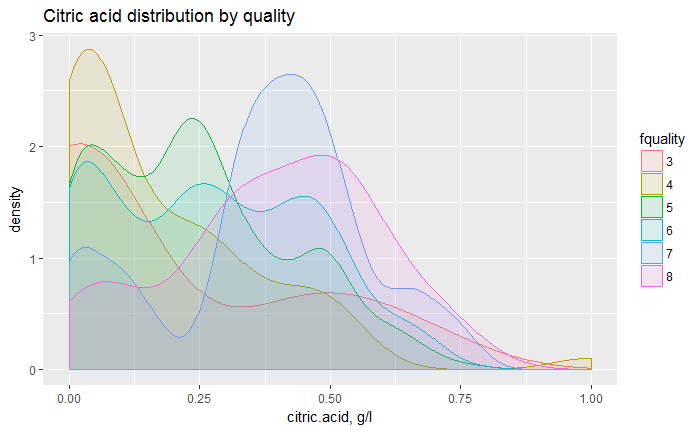

Citric acid is in opposite a good acid but a cause-effect or correlation is smaller.

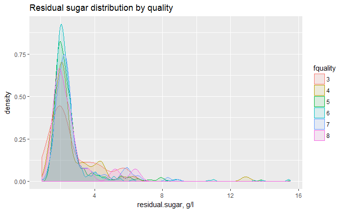

The sugar content does not reflect the quality of the wine at all.

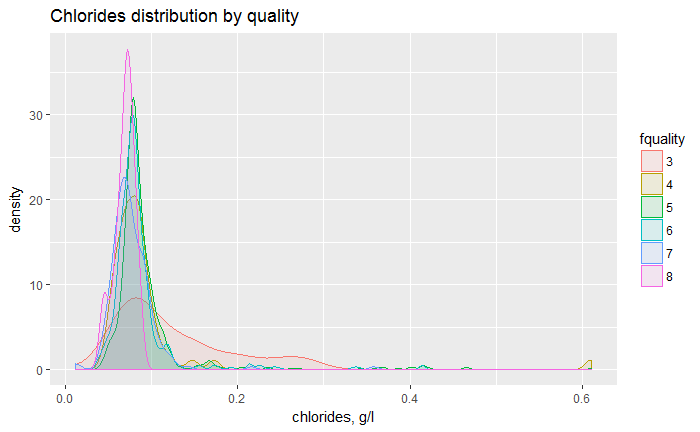

The tail of the distribution of low-quality wine is clearly visible. Wine classes are like-distributed in spite of long tail of outliers.

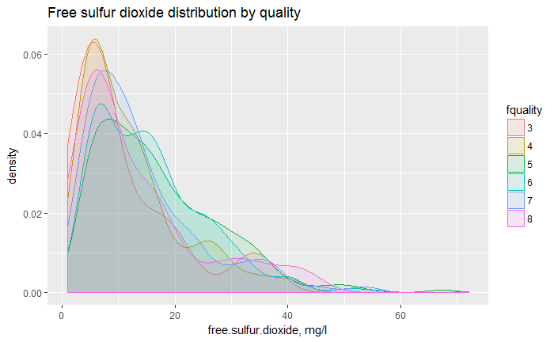

Wine classes are equally distributed throughout the range.

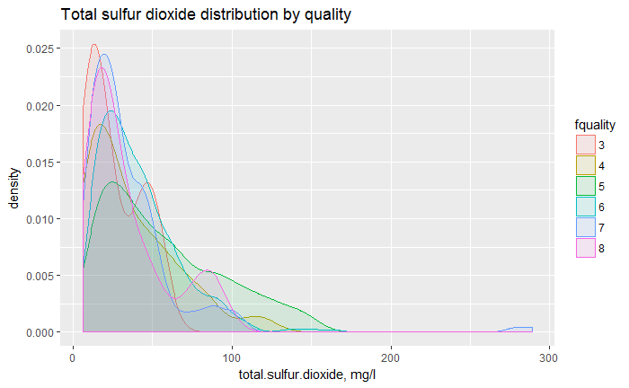

Wine classes are equally distributed throughout the range.

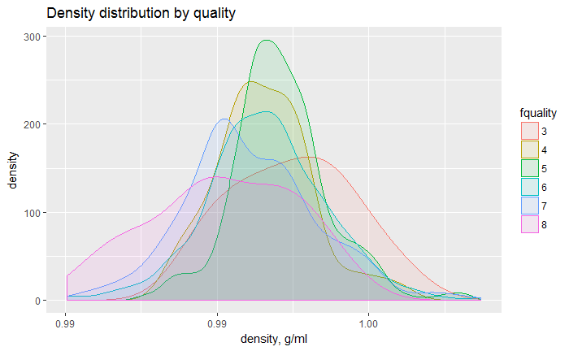

Both boundary classes 3 and 8 are slightly distinguished from the rest. Density is a derived feature gathered other features with opposite effect.

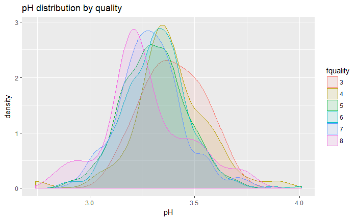

Both boundary classes 3 and 8 are slightly distinguished again. pH is a derived feature too. This property reflects the aggregated acidity of the aqueous solution.

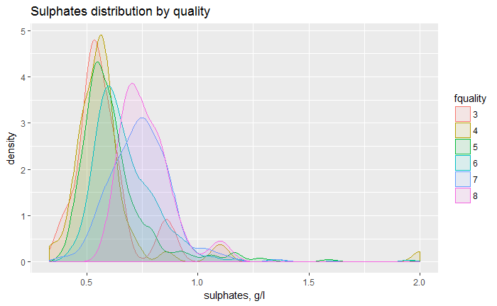

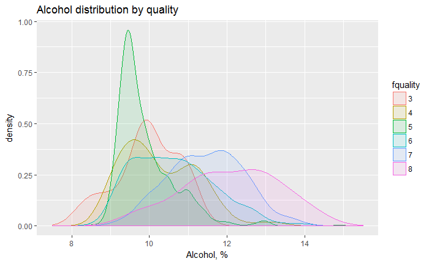

Alcohol distribution has a direct and strongest impact on quality.

It does not make sense to consider all possible combinations of pairs of properties, especially if the correlation coefficient is less than 0.3. Consider pairs of properties that determine the physical parameters of a solution as well as taking into account the effect on the target variable from the previous series of graphs

Lets look at some individual pairs.

Acids distribution:

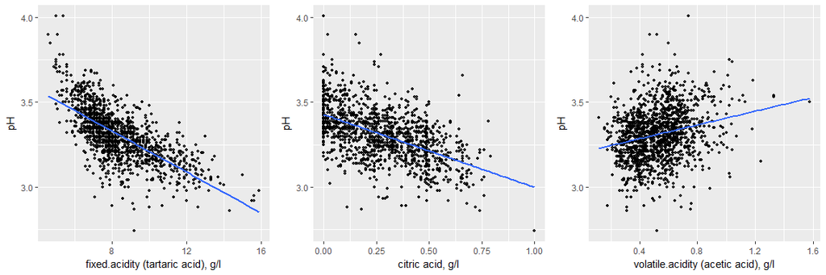

```r
par(mfrow = c(1, 2))
p1 <- ggplot(aes(x=fixed.acidity, y=pH), data=vinho_set) +
  geom_point(alpha = 0.8, size = 1) +
  geom_smooth(method = "lm", se = FALSE, size=1) +
  xlab('fixed.acidity (tartaric acid), g/l')
p2 <- ggplot(aes(x=citric.acid, y=pH), data=vinho_set) +
  geom_point(alpha = 0.8, size = 1) +
  geom_smooth(method = "lm", se = FALSE, size=1) +
  xlab('citric acid, g/l')
p3 <- ggplot(aes(x=volatile.acidity, y=pH), data=vinho_set) +
  geom_point(alpha = 0.8, size = 1) +
  geom_smooth(method = "lm", se = FALSE, size=1) +
  xlab('volatile.acidity (acetic acid), g/l')
grid.arrange(p1, p2, p3, ncol=3)
```

The correlation in the first two pairs are obvious - the pH specifies the acidity of an aqueous solution. Acetic acid is formed inversely proportional to the content of the previous two acids as indicated above in the matrix. A concentration increase of acetic acid leads to an excessive content reduction of both other acids, a decrease in the total acidity and a deterioration in the quality of the wine.

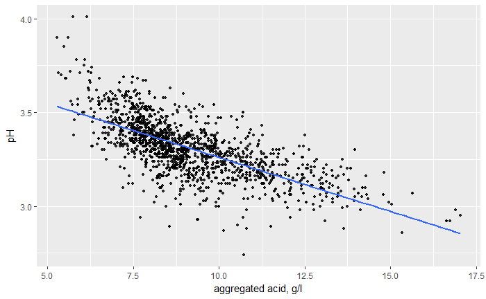

```r
ggplot(aes(x=volatile.acidity+citric.acid+fixed.acidity, y=pH), data=vinho_set) + #
  geom_point(alpha = 0.8, size = 1) +
  geom_smooth(method = "lm", se = FALSE, size=1) +
  xlab('aggregated acid, g/l')
```

The tartaric acid predominates by mass and sets the trend.

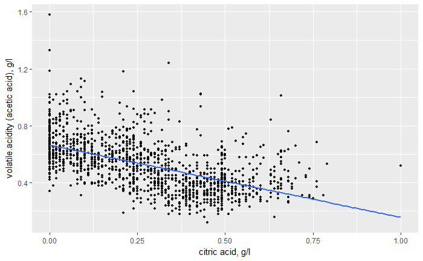

```r
ggplot(aes(x=citric.acid, y=volatile.acidity), data=vinho_set) + #
  geom_point(alpha = 0.8, size = 1) +
  geom_smooth(method = "lm", se = FALSE, size=1) +
  xlab('citric acid, g/l') +
  ylab('volatile.acidity (acetic acid), g/l')
```

The formation of acetic acid decreases with increasing content of citric acid.

The correlation in the next four pairs are obvious too - The graph shows how different concentrations of substances affect the density of the solution.

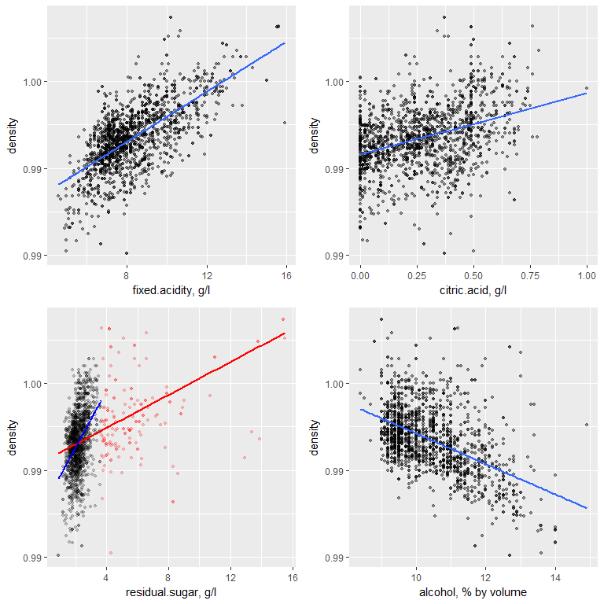

```r
p1 <- ggplot(aes(x=fixed.acidity, y=density), data=vinho_set) +
  geom_point(alpha = 0.4, size = 1) +
  geom_smooth(method = "lm", se = FALSE, size=1) +
  xlab('fixed.acidity, g/l')
p2 <- ggplot(aes(x=citric.acid, y=density), data=vinho_set) +
  geom_point(alpha = 0.4, size = 1) +
  geom_smooth(method = "lm", se = FALSE, size=1) +
  xlab('citric.acid, g/l')
p3 <- ggplot(aes(x=residual.sugar, y=density), data=vinho_set ) +
  geom_point(aes(colour = vinho_set$residual.sugar<3.68), alpha = 0.2, size = 1, show.legend=FALSE) +
  geom_smooth(method = "lm", se = FALSE, size=1, color='red') +
  geom_smooth(method = "lm", se = FALSE, size=1, data=vinho_set[vinho_set$residual.sugar<3.68,], color='blue') +
  scale_color_manual(values=c("red", "black")) +
  xlab('residual.sugar, g/l')
p4 <- ggplot(aes(x=alcohol, y=density), data=vinho_set) +
  geom_point(alpha = 0.4, size = 1) +
  geom_smooth(method = "lm", se = FALSE, size=1) +
  xlab('alcohol, % by volume')
grid.arrange(p1, p2, p3, p4, ncol=2) #, nrow=2
```

Acids and sugar increase the density of the solution, and alcohol reduces it. The predictor residual.sugar has extremely many outliers relative to the rest. Two regression lines show the impact of the outliers (red points). The clear water has a density of 1.0 g/ml.

### Bivariate Analysis

The density distribution of a variable with a low correlation merges into one line and vice versa, a correlation above 0.3 gives a divergence between the density distribution of wines of different qualities.

The second part with scatterplots reflects the physico-chemical properties of the aqueous solution. The study shows the expected correlation of the variables. The dependence of physical properties can help in interpreting the distribution of a qualitative variable.

### Multivariate Plots Section

Lets look at next plots of three variables

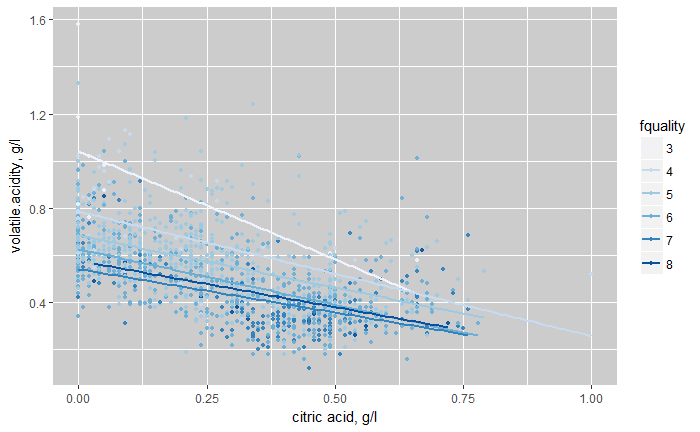

```r
ggplot(aes(x=citric.acid, y=volatile.acidity, colour = fquality), data=vinho_set) + #
  geom_point(alpha = 0.9, size = 1) +
  geom_smooth(method = "lm", se = FALSE, size=1) +
  scale_color_brewer(type='seq') +
  xlab('citric acid, g/l') +
  ylab('volatile.acidity, g/l') +
  theme(panel.background = element_rect(fill = "grey80"))
```

The change in the slope of the lines corresponds to the redistribution of the proportion of acids, depending on the class

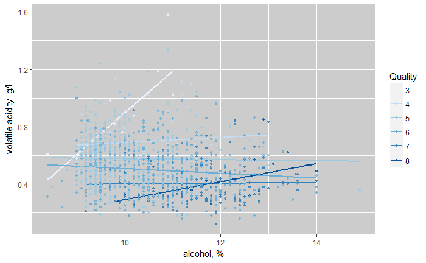

Dependence is visible only among wines of classes 3 and 8. On the graph you can see the color gradient in the direction from the left-top to the right-down.

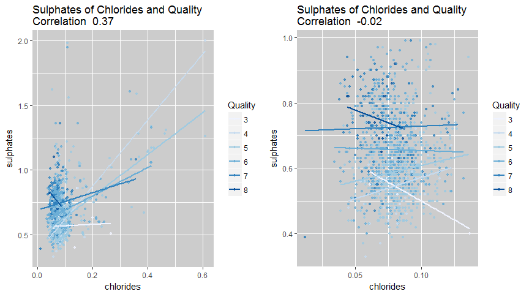

```r
p1 <- ggplot(aes(x=chlorides, y=sulphates, colour = fquality),
       data=vinho_set) +
  geom_point(alpha = 0.8, size = 1) +
  geom_smooth(method = "lm", se = FALSE, size=1) +
  scale_color_brewer(type='seq') +
  labs(colour = 'Quality') +
  ggtitle(paste('Sulphates of Chlorides and Quality\nCorrelation ',
                round(cor(vinho_set$chlorides, vinho_set$sulphates),2))) +
  theme(panel.background = element_rect(fill = "grey80"))
mask <- (vinho_set$chlorides<0.14)&(vinho_set$sulphates<1)
p2 <- ggplot(aes(x=chlorides, y=sulphates, colour = fquality),
       data=vinho_set[mask,]) +
  geom_point(alpha = 0.8, size = 1) +
  geom_smooth(method = "lm", se = FALSE, size=1) +
  scale_color_brewer(type='seq') +
  labs(colour = 'Quality') +
  ggtitle(paste('Sulphates of Chlorides and Quality\nCorrelation ',
                round(cor(vinho_set[mask,]$chlorides, vinho_set[mask,]$sulphates),2))) +
  theme(panel.background = element_rect(fill = "grey80"))
grid.arrange(p1, p2, ncol=2)
```

By discarding the outliers only (on the right plot) we can see the inverse relationship in classes 3 and 8 and the change in the nature of the total correlation from positive to zero.

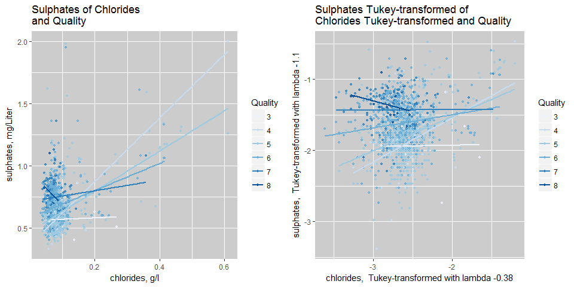

```r
p1 <- ggplot(vinho_set[(vinho_set$chlorides > 0.02),],
        aes(x=chlorides,
            y=sulphates, colour = fquality)) +
        geom_point(alpha = 0.8, size = 1) +
        ylab('sulphates, mg/Liter') +
        xlab('chlorides, g/l') +
        geom_smooth(method = "lm", se = FALSE, size=1) +
        ggtitle('Sulphates of Chlorides\nand Quality') +
        scale_color_brewer(type='seq') +
        labs(colour = 'Quality') +
        theme(panel.background = element_rect(fill = "grey80"))
p2 <- ggplot(vinho_set[(vinho_set$chlorides > 0.02),],
        aes(x=-1/(chlorides^0.38),
            y=-1/(sulphates^1.1), colour = fquality)) +
        geom_point(alpha = 0.8, size = 1) +
        ylab('sulphates,  Tukey-transformed with lambda -1.1') +
        xlab('chlorides,  Tukey-transformed with lambda -0.38') +
        geom_smooth(method = "lm", se = FALSE, size=1) +
        ggtitle('Sulphates Tukey-transformed of\nChlorides Tukey-transformed and Quality') +
        scale_color_brewer(type='seq') +
        labs(colour = 'Quality') +
        theme(panel.background = element_rect(fill = "grey80"))
grid.arrange(p1, p2, ncol=2)
```

Normalization on both axes does not change the relationship. There is no clear clusters, but a small gradient along axis y.

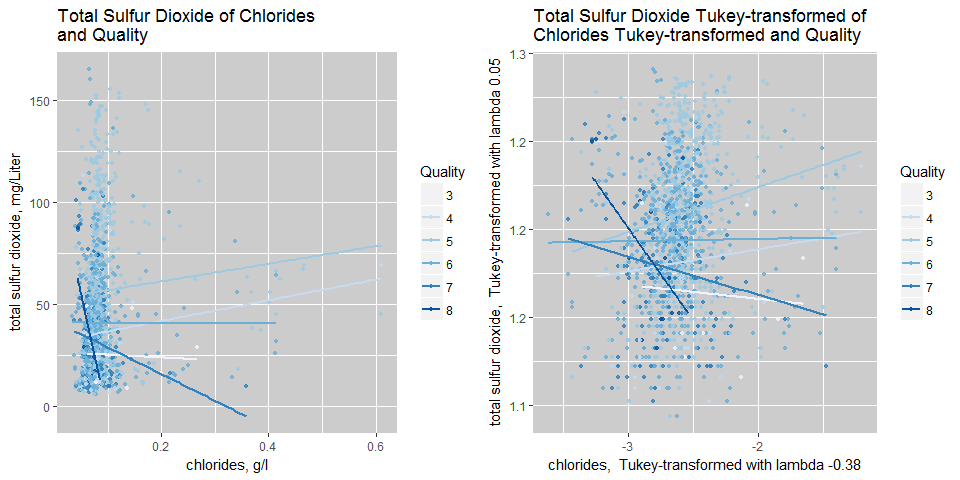

```r
p1 <- ggplot(vinho_set[(vinho_set$chlorides > 0.02)&(vinho_set$total.sulfur.dioxide<250),],
        aes(x=chlorides,
            y=total.sulfur.dioxide, colour = fquality)) +
        geom_point(alpha = 0.8, size = 1) +
        ylab('total sulfur dioxide, mg/Liter') +
        xlab('chlorides, g/l') +
        geom_smooth(method = "lm", se = FALSE, size=1) +
        ggtitle('Total Sulfur Dioxide of Chlorides\nand Quality') +
        scale_color_brewer(type='seq') +
        labs(colour = 'Quality') +
        theme(panel.background = element_rect(fill = "grey80"))
p2 <- ggplot(vinho_set[(vinho_set$chlorides > 0.02)&(vinho_set$total.sulfur.dioxide<250),],
        aes(x=-1/(chlorides^0.38),
            y=total.sulfur.dioxide^0.05, colour = fquality)) +
        geom_point(alpha = 0.8, size = 1) +
        ylab('total sulfur dioxide,  Tukey-transformed with lambda 0.05') +
        xlab('chlorides,  Tukey-transformed with lambda -0.38') +
        geom_smooth(method = "lm", se = FALSE, size=1) +
        ggtitle('Total Sulfur Dioxide Tukey-transformed of\nChlorides Tukey-transformed and Quality') +
        scale_color_brewer(type='seq') +
        labs(colour = 'Quality') +
        theme(panel.background = element_rect(fill = "grey80"))
grid.arrange(p1, p2, ncol=2)
```

Normalization on both axes does not change the relationship. There is no clear gradient in any direction. A small correlation of variables is noticeable on these graphs. There is no clear clusters, but a small gradient along axis y.

### Multivariate Analysis

Let’s investigate the behavior of the linear model using the information presented above. First, a model without of any predictors changes is shown:

```r
options(digits=3)
nn1 <- paste(names(vinho_set[,c(2:12)]), collapse = '+')
ff <- as.formula(paste("quality ~", nn1))
lm1 <- lm(formula = ff, data = vinho_set)
summary(lm1)
```

```
Call:
lm(formula = ff, data = vinho_set)

Residuals:
   Min     1Q Median     3Q    Max
-2.689 -0.366 -0.047  0.452  2.025

Coefficients:
                      Estimate Std. Error t value Pr(>|t|)
(Intercept)           2.20e+01   2.12e+01    1.04    0.300
fixed.acidity         2.50e-02   2.59e-02    0.96    0.336
volatile.acidity     -1.08e+00   1.21e-01   -8.95  < 2e-16 ***
citric.acid          -1.83e-01   1.47e-01   -1.24    0.215
residual.sugar        1.63e-02   1.50e-02    1.09    0.276
chlorides            -1.87e+00   4.19e-01   -4.47  8.4e-06 ***
free.sulfur.dioxide   4.36e-03   2.17e-03    2.01    0.045 *
total.sulfur.dioxide -3.27e-03   7.29e-04   -4.48  8.0e-06 ***
density              -1.79e+01   2.16e+01   -0.83    0.409
pH                   -4.14e-01   1.92e-01   -2.16    0.031 *
sulphates             9.16e-01   1.14e-01    8.01  2.1e-15 ***
alcohol               2.76e-01   2.65e-02   10.43  < 2e-16 ***
---
Signif. codes:  0 ‘***’ 0.001 ‘**’ 0.01 ‘*’ 0.05 ‘.’ 0.1 ‘ ’ 1

Residual standard error: 0.648 on 1587 degrees of freedom
Multiple R-squared:  0.361, Adjusted R-squared:  0.356
F-statistic: 81.3 on 11 and 1587 DF,  p-value: <2e-16
```

The greatest error is observed by the variable density, the removal of this variable slightly improves the F-statistic. Removing the others three variables (fixed.acidity, citric.acid, residual.sugar) with the probability greater than 5% in the column Pr(>|t|) improves F-statistic while maintaining the accuracy:

```r
nn1 <- paste(names(vinho_set[,c(3,6:8,10,11,12)]), collapse = '+')
ff <- as.formula(paste("quality ~", nn1))
lm1 <- lm(formula = ff, data = vinho_set)
summary(lm1)
```

```
Call:
lm(formula = ff, data = vinho_set)

Residuals:
    Min      1Q  Median      3Q     Max
-2.6892 -0.3676 -0.0465  0.4608  2.0295

Coefficients:
                      Estimate Std. Error t value             Pr(>|t|)
(Intercept)           4.430099   0.402917   11.00 < 0.0000000000000002 ***
volatile.acidity     -1.012753   0.100843  -10.04 < 0.0000000000000002 ***
chlorides            -2.017814   0.397542   -5.08   0.0000004313716589 ***
free.sulfur.dioxide   0.005077   0.002126    2.39                0.017 *
total.sulfur.dioxide -0.003482   0.000687   -5.07   0.0000004434833552 ***
pH                   -0.482661   0.117558   -4.11   0.0000423496231472 ***
sulphates             0.882665   0.109908    8.03   0.0000000000000019 ***
alcohol               0.289303   0.016796   17.22 < 0.0000000000000002 ***
---
Signif. codes:  0 ‘***’ 0.001 ‘**’ 0.01 ‘*’ 0.05 ‘.’ 0.1 ‘ ’ 1

Residual standard error: 0.65 on 1591 degrees of freedom
Multiple R-squared:  0.359, Adjusted R-squared:  0.357
F-statistic:  128 on 7 and 1591 DF,  p-value: <0.0000000000000002
```

Let’s compare it with normalized distribution. The Tukey ladder of powers is used:

```
Call:
lm(formula = ff, data = vinho_set)

Residuals:
    Min      1Q  Median      3Q     Max
-2.6811 -0.3722 -0.0413  0.4309  2.0703

Coefficients:
                                                      Estimate Std. Error t value Pr(>|t|)
(Intercept)                                             1.5112     2.0627    0.73   0.4639
transformTukey(fixed.acidity, plotit = FALSE)           4.1883     1.3106    3.20   0.0014 **
transformTukey(volatile.acidity, plotit = FALSE)       -1.7706     0.2197   -8.06  1.5e-15 ***
transformTukey(citric.acid, plotit = FALSE)            -0.2569     0.1269   -2.02   0.0432 *
transformTukey(residual.sugar, plotit = FALSE)          0.5119     0.1641    3.12   0.0018 **
transformTukey(chlorides, plotit = FALSE)              -0.2606     0.0643   -4.05  5.4e-05 ***
transformTukey(free.sulfur.dioxide, plotit = FALSE)     0.3333     0.1811    1.84   0.0659 .
transformTukey(total.sulfur.dioxide, plotit = FALSE)   -2.1524     0.6816   -3.16   0.0016 **
transformTukey(density, plotit = FALSE)                -7.2019     1.9883   -3.62   0.0003 ***
transformTukey(pH, plotit = FALSE)                     -3.2808     2.9039   -1.13   0.2587
transformTukey(sulphates, plotit = FALSE)               0.5720     0.0512   11.17  < 2e-16 ***
transformTukey(alcohol, plotit = FALSE)              3520.4786   436.0990    8.07  1.3e-15 ***
---
Signif. codes:  0 ‘***’ 0.001 ‘**’ 0.01 ‘*’ 0.05 ‘.’ 0.1 ‘ ’ 1

Residual standard error: 0.643 on 1587 degrees of freedom
Multiple R-squared:  0.37,  Adjusted R-squared:  0.366
F-statistic: 84.9 on 11 and 1587 DF,  p-value: <2e-16
```

Two predictors pH and free.sulfur.dioxide have the probability greater than 5% in the column Pr(>|t|) and can be removed from the consideration. The transformed predictor alcohol has received the worst value in the column Std. Error. The original unchanged value is preferably.

```
Call:
lm(formula = ff, data = vinho_set)

Residuals:
    Min      1Q  Median      3Q     Max
-2.6581 -0.3713 -0.0442  0.4310  1.9429

Coefficients:
                                                     Estimate Std. Error t value Pr(>|t|)
(Intercept)                                            0.9430     1.5967    0.59  0.55486
alcohol                                                0.2189     0.0233    9.39  < 2e-16 ***
transformTukey(fixed.acidity, plotit = FALSE)          5.1734     0.9397    5.51  4.3e-08 ***
transformTukey(volatile.acidity, plotit = FALSE)      -1.8481     0.2165   -8.54  < 2e-16 ***
transformTukey(citric.acid, plotit = FALSE)           -0.3384     0.1235   -2.74  0.00622 **
transformTukey(residual.sugar, plotit = FALSE)         0.4389     0.1629    2.69  0.00712 **
transformTukey(chlorides, plotit = FALSE)             -0.2377     0.0629   -3.78  0.00016 ***
transformTukey(total.sulfur.dioxide, plotit = FALSE)  -1.1080     0.4155   -2.67  0.00774 **
transformTukey(density, plotit = FALSE)               -6.7057     1.7647   -3.80  0.00015 ***
transformTukey(sulphates, plotit = FALSE)              0.5635     0.0510   11.06  < 2e-16 ***
---
Signif. codes:  0 ‘***’ 0.001 ‘**’ 0.01 ‘*’ 0.05 ‘.’ 0.1 ‘ ’ 1

Residual standard error: 0.641 on 1589 degrees of freedom
Multiple R-squared:  0.374, Adjusted R-squared:  0.371
F-statistic:  106 on 9 and 1589 DF,  p-value: <2e-16
```

In comparison with the original version it was possible to increase the accuracy of the approximation by 4%, improve F-statistic, reduce the complexity of the model by removing of two predictors.

As a next step, it would be possible to delete observations with outliers. The methods based on z-score or z-score with MAD can be used for the normal distributed predictors or a Tukey’s fences can be used for the skewed predictors.

The linear model is highly sensitive to the characteristics of individual variables and very poorly approximates the distribution of the real wine data.

The svm-based model mentioned in the [original study](http://dx.doi.org/10.1016/j.dss.2009.05.016) is not sensitive to the distribution kind of variables and gives the worst predictions by any transformation (compared with centred-scaled, PCA, ICA and Box-Cox transformation). Only repeated K–fold cross–validation is used. The final parameters used for the model were sigma = 0.0784541 and C = 2.

The full connected neural network with three hidden layers (15, 11 and 8 neurons accordingly) gives slightly better predictions and also does not require any transformations. The logistic activation function is used. Removing data of classes 3 and 8 givs an improvement in prediction.

## Final Plots and Summary

### Plot 1

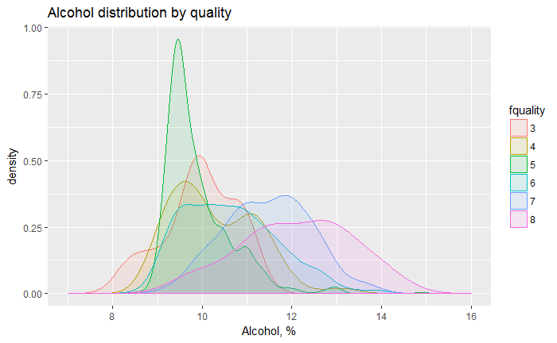

### Plot 2

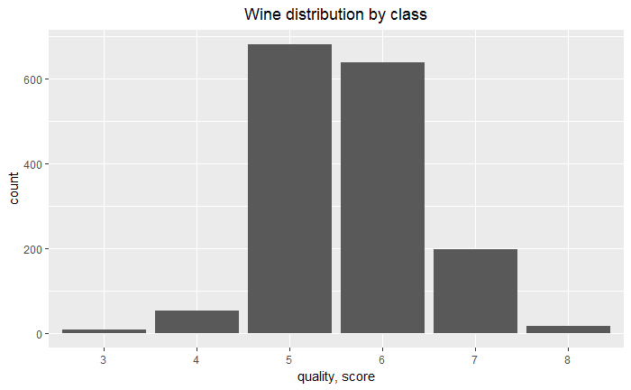

```r
ggplot(data=vinho_set, stat="count", aes_string(x='fquality')) +
  geom_bar() +
  xlab('quality, score') +
  ggtitle('Wine distribution by class')
```

```r
  #geom_histogram(colour="black", fill="white")
```

This graph shows an extremely uneven data distribution by the target variable quality. Tukey’s fences method considers the first and last classes of the variable as outliers. Removing data of classes 3 and 8 (10 and 18 observations) givs an improvement in prediction of the full connected neural network.

### Plot 3

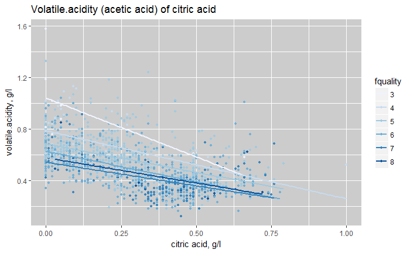

```r
ggplot(aes(x=citric.acid, y=volatile.acidity, colour = fquality), data=vinho_set) + #
  geom_point(alpha = 0.9, size = 1) +
  geom_smooth(method = "lm", se = FALSE, size=1) +
  scale_color_brewer(type='seq') +
  xlab('citric acid, g/l') +
  ylab('volatile.acidity, g/l') +
  theme(panel.background = element_rect(fill = "grey80")) +
  ggtitle('Volatile.acidity (acetic acid) of citric acid')
```

## Reflection

As far as I know this is the first dataset of considerable volume dedicated to the winemaking. There are no missing values in the data, but there are outliers, by the nature of which I can not speak of an error. The most difficult for me was the subjective nature of the wine classification, which led to the absence of noticeable clusters and a large error of linear regression. On the other hand, I was sure that the model on the neural network gives a prediction near or better than other nonlinear models and found such a configuration. In the process of optimization I found out that linear and nonlinear regression as well as neural network have completely different sensitivity to outliers, skewness and various data conversions.